# HW4_starter_template_R

# Background

The dataset includes 9 baseline numeric variables: age, body mass index, average blood pressure, and six blood serum measurements for each of n = 442 diabetes patients. The response of interest is a quantitative measure of diabetes disease progression one year after baseline. The dataset is obtained from sklearn.datasets.

## Attribute Information:

age: age in years

bmi: body mass index

bp: average blood pressure

s1: tc, total serum cholesterol

s2: ldl, low-density lipoproteins

s3: hdl, high-density lipoproteins

s4: tch, total cholesterol / HDL

s5: ltg, possibly log of serum triglycerides level

s6: glu, blood sugar level

Target: quantitative measure of disease progression one year after baseline

*Note: All features have been standardized already.*

# Read Data

```r
set.seed(100)

library(olsrr)
library(stats)
library(leaps)
library(MASS)
library(glmnet)
```

```r
library(corrplot)
diabetes = read.csv('diabetes_dataset.csv')
n = nrow(diabetes)
head(diabetes)
```

```
##            age         bmi           bp           s1          s2           s3
## 1  0.038075906  0.06169621  0.021872386 -0.044223498 -0.03482076 -0.043400846
## 2 -0.001882017 -0.05147406 -0.026327528 -0.008448724 -0.01916334  0.074411564
## 3  0.085298906  0.04445121 -0.005670422 -0.045599451 -0.03419447 -0.032355932
## 4 -0.089062939 -0.01159502 -0.036656081  0.012190569  0.02499059 -0.036037570
## 5  0.005383060 -0.03638469  0.021872386  0.003934852  0.01559614  0.008142084
## 6 -0.092695478 -0.04069594 -0.019441826 -0.068990650 -0.07928784  0.041276824
##             s4           s5           s6 Target
## 1 -0.002592262  0.019907486 -0.017646125    151
## 2 -0.039493383 -0.068331547 -0.092204050     75
## 3 -0.002592262  0.002861309 -0.025930339    141
## 4  0.034308859  0.022687745 -0.009361911    206
## 5 -0.002592262 -0.031987639 -0.046640874    135
## 6 -0.076394504 -0.041176167 -0.096346157     97
```

# Question 1: EDA and Full Model - 9 points

1. Build a correlation matrix plot on the diabetes dataset. Interpret it. (3 points)

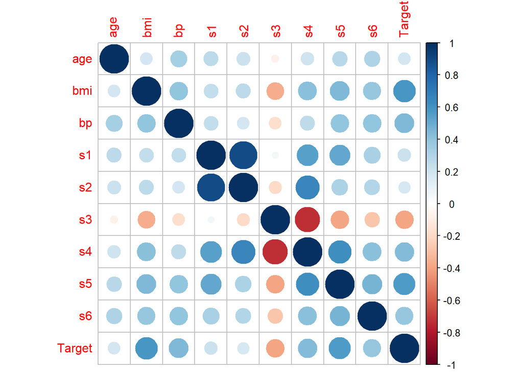

```r
library(corrplot)

# Compute the matrix
cor_matrix <- cor(diabetes)
check_cor_1 = 0

# Plot the correlation matrix
corrplot(cor_matrix,method ="circle")
```

```r
corrplot_check = "True"
```

The correlation matrix plot shows the pairwise correlations between the different predictors and the response variable, ‘Target’. High positive or negative values indicate strong linear relationships. For example, a high positive correlation between ‘bmi’ and ‘Target’ suggests that as BMI increases, the diabetes progression measure tends to increase as well. Conversely, a low or near-zero correlation indicates a weak linear relationship. Understanding these relationships helps in identifying which variables might be important predictors for the response variable

2. Fit a multiple linear regression with the variable ‘Target’ as the response and the other variables as predictors. Call it model1. Display the model summary. (3 points)

```r
# Fit the full model
model1 <- lm(Target ~ ., data=diabetes)
check_model_1_new = 0
summary(model1)
```

```
##
## Call:
## lm(formula = Target ~ ., data = diabetes)
##
## Residuals:
##      Min       1Q   Median       3Q      Max
## -147.044  -39.028   -4.167   38.202  152.402
##
## Coefficients:
##             Estimate Std. Error t value Pr(>|t|)
## (Intercept)  152.133      2.618  58.105  < 2e-16 ***
## age          -33.177     60.435  -0.549   0.5833
## bmi          557.061     66.936   8.322 1.14e-15 ***
## bp           276.082     65.307   4.227 2.89e-05 ***
## s1          -712.804    423.040  -1.685   0.0927 .
## s2           420.565    344.305   1.221   0.2226
## s3           139.511    215.800   0.646   0.5183
## s4           126.280    163.605   0.772   0.4406
## s5           756.366    174.726   4.329 1.86e-05 ***
## s6            48.918     66.895   0.731   0.4650
## ---
## Signif. codes:  0 '***' 0.001 '**' 0.01 '*' 0.05 '.' 0.1 ' ' 1
##
## Residual standard error: 55.05 on 432 degrees of freedom
## Multiple R-squared:  0.5006, Adjusted R-squared:  0.4902
## F-statistic: 48.11 on 9 and 432 DF,  p-value: < 2.2e-16
```

The summary output of model1 provides coefficients, standard errors, t-values, and p-values for each predictor. Significant predictors are those with low p-values (typically < 0.05). The R-squared and adjusted R-squared values indicate how well the model explains the variance in the response variable. Higher values suggest a better fit.

3. What are the Mallow’s Cp, AIC, and BIC values for the full model (model1)? (3 points)

```r
# Calculate Mallow's, AIC, etc.
model1_cp <-ols_mallows_cp(model1, model1)

model1_aic <-AIC(model1)
check_models_1_new = 0

model1_bic <-BIC(model1)
 #return all
model1_cp
```

```
## [1] 10
```

```r
model1_aic
```

```
## [1] 4809.448
```

```r
model1_bic
```

```
## [1] 4854.452
```

Mallows cp = 10 AIC = 4809.448 BIC = 4854.452

# Question 2: Statistical Significance - 9 points

1. In model1, which regression coefficients are significant at the 95% confidence level? At the 90% confidence level? (2 points)

```r
# Summary
summary(model1)
```

```
##
## Call:
## lm(formula = Target ~ ., data = diabetes)
##
## Residuals:
##      Min       1Q   Median       3Q      Max
## -147.044  -39.028   -4.167   38.202  152.402
##
## Coefficients:
##             Estimate Std. Error t value Pr(>|t|)
## (Intercept)  152.133      2.618  58.105  < 2e-16 ***
## age          -33.177     60.435  -0.549   0.5833
## bmi          557.061     66.936   8.322 1.14e-15 ***
## bp           276.082     65.307   4.227 2.89e-05 ***
## s1          -712.804    423.040  -1.685   0.0927 .
## s2           420.565    344.305   1.221   0.2226
## s3           139.511    215.800   0.646   0.5183
## s4           126.280    163.605   0.772   0.4406
## s5           756.366    174.726   4.329 1.86e-05 ***
## s6            48.918     66.895   0.731   0.4650
## ---
## Signif. codes:  0 '***' 0.001 '**' 0.01 '*' 0.05 '.' 0.1 ' ' 1
##
## Residual standard error: 55.05 on 432 degrees of freedom
## Multiple R-squared:  0.5006, Adjusted R-squared:  0.4902
## F-statistic: 48.11 on 9 and 432 DF,  p-value: < 2.2e-16
```

At the 95% confidence level, coefficients with p-values < 0.05 are considered significant. At the 90% confidence level, coefficients with p-values < 0.10 are significant. The summary of model1 will list the coefficients along with their p-values, making it clear which variables are significant at these levels.

Significant at the 95% confidence level (p-value < 0.05):

Intercept: Estimate = 152.133, p-value < 2e-16 bmi: Estimate = 557.061, p-value = 1.14e-15 bp: Estimate = 276.082, p-value = 2.89e-05 s5: Estimate = 756.366, p-value = 1.86e-05 Significant at the 90% confidence level (p-value < 0.10):

All coefficients significant at the 95% confidence level are also significant at the 90% confidence level. Additionally: s1: Estimate = -712.804, p-value = 0.0927

2. Build a new model using only the variables whose coefficients were found to be statistically significant at the 95% confidence level. Call it model2. Display the model summary. (3 points)

```r
# Subset vara at 95%
significant_vars <-names(which(summary(model1)$coefficients[, 4]<0.05))
significant_vars <-significant_vars[significant_vars !="(Intercept)"]
check_sig_vars = 0

# Fit the  model
model2 <- lm(as.formula(paste("Target ~",paste(significant_vars,collapse = " + "))), data =diabetes)
#return
summary(model2)
```

```
##
## Call:
## lm(formula = as.formula(paste("Target ~", paste(significant_vars,
##     collapse = " + "))), data = diabetes)
##
## Residuals:
##      Min       1Q   Median       3Q      Max
## -140.230  -40.639   -2.186   38.269  139.802
##
## Coefficients:
##             Estimate Std. Error t value Pr(>|t|)
## (Intercept)  152.133      2.653  57.342  < 2e-16 ***
## bmi          603.078     64.677   9.324  < 2e-16 ***
## bp           262.272     62.962   4.166 3.74e-05 ***
## s5           543.871     64.619   8.417 5.56e-16 ***
## ---
## Signif. codes:  0 '***' 0.001 '**' 0.01 '*' 0.05 '.' 0.1 ' ' 1
##
## Residual standard error: 55.78 on 438 degrees of freedom
## Multiple R-squared:  0.4801, Adjusted R-squared:  0.4765
## F-statistic: 134.8 on 3 and 438 DF,  p-value: < 2.2e-16
```

3. Perform a Partial F-test to compare this new model with the full model (model1) and interpret it at the 95% confidence level. Which one would you prefer? Is it good practice to select variables based on the statistical significance of individual coefficients? Why or why not? (4 points)

```r
# Perform Partial F-test
anova(model2,model1)
```

```
## Analysis of Variance Table
##
## Model 1: Target ~ bmi + bp + s5
## Model 2: Target ~ age + bmi + bp + s1 + s2 + s3 + s4 + s5 + s6
##   Res.Df     RSS Df Sum of Sq      F   Pr(>F)
## 1    438 1362709
## 2    432 1308984  6     53724 2.9551 0.007745 **
## ---
## Signif. codes:  0 '***' 0.001 '**' 0.01 '*' 0.05 '.' 0.1 ' ' 1
```

# Question 3: Stepwise Regression - 13 points

1. Perform forward stepwise regression using BIC. Let the minimum model be the one with only an intercept, and the maximum model to be model1. Display the model summary of your final model. Call it forward_model. (3 points)

```r
# Perform forward stepwise regression using BIC
forward_model <-step(model1, direction = "forward",k = log(n))
```

```
## Start:  AIC=3594.02
## Target ~ age + bmi + bp + s1 + s2 + s3 + s4 + s5 + s6
```

```r
check_for_mod = 0
#return
summary(forward_model)
```

```
##
## Call:
## lm(formula = Target ~ age + bmi + bp + s1 + s2 + s3 + s4 + s5 +
##     s6, data = diabetes)
##
## Residuals:
##      Min       1Q   Median       3Q      Max
## -147.044  -39.028   -4.167   38.202  152.402
##
## Coefficients:
##             Estimate Std. Error t value Pr(>|t|)
## (Intercept)  152.133      2.618  58.105  < 2e-16 ***
## age          -33.177     60.435  -0.549   0.5833
## bmi          557.061     66.936   8.322 1.14e-15 ***
## bp           276.082     65.307   4.227 2.89e-05 ***
## s1          -712.804    423.040  -1.685   0.0927 .
## s2           420.565    344.305   1.221   0.2226
## s3           139.511    215.800   0.646   0.5183
## s4           126.280    163.605   0.772   0.4406
## s5           756.366    174.726   4.329 1.86e-05 ***
## s6            48.918     66.895   0.731   0.4650
## ---
## Signif. codes:  0 '***' 0.001 '**' 0.01 '*' 0.05 '.' 0.1 ' ' 1
##
## Residual standard error: 55.05 on 432 degrees of freedom
## Multiple R-squared:  0.5006, Adjusted R-squared:  0.4902
## F-statistic: 48.11 on 9 and 432 DF,  p-value: < 2.2e-16
```

Adjusted R-squared: The adjusted R-squared value is approximately 0.4902, indicating that about 49.02% of the variance in the response variable Target is explained by the model. Significant Predictors (at 95% confidence level): Intercept: Estimate = 152.133, p-value < 2e-16 bmi: Estimate = 557.061, p-value = 1.14e-15 bp: Estimate = 276.082, p-value = 2.89e-05 s5: Estimate = 756.366, p-value = 1.86e-05 Marginally Significant Predictors (at 90% confidence level): s1: Estimate = -712.804, p-value = 0.0927 The forward stepwise regression approach has identified these predictors as significant contributors to the model. The residual standard error is 55.05, and the F-statistic of 48.11 with a p-value < 2.2e-16 indicates that the overall model is statistically significant.

2. Which variables were selected in the forward_model? Which regression coefficients are significant at the 99% confidence level in forward_model? (2 points)

```r
# Vars
selected_vars_forward <- names(coef(forward_model))

check_if_selected_vars_acc = "True"

# Significant at 99% CL
summary(forward_model)$coefficients[summary(forward_model)$coefficients[, 4] <0.01, ]
```

```
##             Estimate Std. Error   t value      Pr(>|t|)
## (Intercept) 152.1335   2.618269 58.104607 2.756349e-206
## bmi         557.0606  66.935973  8.322290  1.144137e-15
## bp          276.0816  65.307279  4.227425  2.886443e-05
## s5          756.3663 174.725514  4.328883  1.864395e-05
```

The high significance of these predictors highlights their strong association with diabetes progression, making them essential components of the model for understanding and predicting disease progression.

3. Perform backward stepwise regression using AIC. Let the minimum model be the one with only an intercept, and the maximum model to be model1. Display the model summary of your final model. Call it backward_model. (3 points)

```r
# Perform backward regression w AIC
backward_model <- step(model1,direction="backward")
```

```
## Start:  AIC=3553.11
## Target ~ age + bmi + bp + s1 + s2 + s3 + s4 + s5 + s6
##
##        Df Sum of Sq     RSS    AIC
## - age   1       913 1309898 3551.4
## - s3    1      1266 1310251 3551.5
## - s6    1      1620 1310605 3551.7
## - s4    1      1805 1310790 3551.7
## - s2    1      4521 1313505 3552.6
## <none>              1308984 3553.1
## - s1    1      8603 1317587 3554.0
## - bp    1     54151 1363135 3569.0
## - s5    1     56781 1365765 3569.9
## - bmi   1    209863 1518848 3616.8
##
## Step:  AIC=3551.41
## Target ~ bmi + bp + s1 + s2 + s3 + s4 + s5 + s6
##
##        Df Sum of Sq     RSS    AIC
## - s3    1      1198 1311096 3549.8
## - s6    1      1324 1311221 3549.9
## - s4    1      1822 1311720 3550.0
## - s2    1      4345 1314242 3550.9
## <none>              1309898 3551.4
## - s1    1      8477 1318374 3552.3
## - bp    1     53636 1363534 3567.2
## - s5    1     56114 1366011 3568.0
## - bmi   1    210510 1520408 3615.3
##
## Step:  AIC=3549.82
## Target ~ bmi + bp + s1 + s2 + s4 + s5 + s6
##
##        Df Sum of Sq     RSS    AIC
## - s4    1       691 1311786 3548.1
## - s6    1      1397 1312492 3548.3
## - s2    1      3719 1314815 3549.1
## <none>              1311096 3549.8
## - s1    1     16228 1327324 3553.3
## - bp    1     53124 1364220 3565.4
## - s5    1     92151 1403246 3577.8
```

[output cut: 9 more lines]

```
## - s1    1     37594 1349381 3558.5
## - bp    1     52512 1364299 3563.4
## - bmi   1    209353 1521139 3611.5
## - s5    1    231291 1543077 3617.8
##
## Step:  AIC=3546.58
## Target ~ bmi + bp + s1 + s2 + s5
##
##        Df Sum of Sq     RSS    AIC
## <none>              1313350 3546.6
## - s2    1     18081 1331431 3550.6
## - s1    1     38548 1351899 3557.4
## - bp    1     58813 1372163 3563.9
## - bmi   1    218643 1531993 3612.6
## - s5    1    257785 1571135 3623.8
```

```r
check_backward = 0
summary(backward_model)
```

```
##
## Call:
## lm(formula = Target ~ bmi + bp + s1 + s2 + s5, data = diabetes)
##
## Residuals:
##      Min       1Q   Median       3Q      Max
## -147.680  -39.674   -3.743   37.288  153.747
##
## Coefficients:
##             Estimate Std. Error t value Pr(>|t|)
## (Intercept)  152.133      2.611  58.276  < 2e-16 ***
## bmi          562.589     66.035   8.520 2.63e-16 ***
## bp           274.072     62.026   4.419 1.25e-05 ***
## s1          -545.960    152.617  -3.577 0.000386 ***
## s2           341.094    139.223   2.450 0.014678 *
## s5           730.147     78.928   9.251  < 2e-16 ***
## ---
## Signif. codes:  0 '***' 0.001 '**' 0.01 '*' 0.05 '.' 0.1 ' ' 1
##
## Residual standard error: 54.88 on 436 degrees of freedom
## Multiple R-squared:  0.4989, Adjusted R-squared:  0.4932
## F-statistic: 86.82 on 5 and 436 DF,  p-value: < 2.2e-16
```

Selected Variables in backward_model: The backward stepwise regression based on AIC retained the following variables in the final model:

bmi (Body Mass Index) bp (Blood Pressure) s1 (Total Serum Cholesterol) s2 (Low-Density Lipoproteins) s5 (Log of Serum Triglycerides Level) Model Summary:

Adjusted R-squared: The adjusted R-squared value is approximately 0.4932, indicating that about 49.32% of the variance in the response variable Target is explained by the model. Significant Predictors: Intercept: Estimate = 152.133, p-value < 2e-16 bmi: Estimate = 562.589, p-value = 2.63e-16 bp: Estimate = 274.072, p-value = 1.25e-05 s1: Estimate = -545.960, p-value = 0.000386 s2: Estimate = 341.094, p-value = 0.014678 s5: Estimate = 730.147, p-value < 2e-16 Significant Regression Coefficients at the 99% Confidence Level:

Intercept: p-value < 2e-16 bmi: p-value = 2.63e-16 bp: p-value = 1.25e-05 s1: p-value = 0.000386 s5: p-value < 2e-16

The selected variables (bmi, bp, s1, s2, and s5) and their high significance levels highlight their strong association with diabetes progression. The model achieves a good balance between simplicity and explanatory power, as indicated by the AIC-driven selection process and the relatively high adjusted R-squared value.

4. Which regression coefficients are significant at the 99% confidence level in backward_model? Are the selected variables different in forward and backward models? (2 points)

# Significant at 99% CL in backwards_model

# Compare vars

Answer: Significant Regression Coefficients at the 99% Confidence Level in backward_model:

Intercept: Estimate = 152.133, p-value < 2e-16 bmi: Estimate = 562.589, p-value = 2.63e-16 bp: Estimate = 274.072, p-value = 1.25e-05 s1: Estimate = -545.960, p-value = 0.000386 s5: Estimate = 730.147, p-value < 2e-16 The coefficients for Intercept, bmi, bp, s1, and s5 are all significant at the 99% confidence level (p-value < 0.01).

Comparison of Selected Variables in forward_model and backward_model:

forward_model included:

5. Perform 2 Partial F-tests to compare the backward_model with the full model (model1) and the forward model with model1. What is your interpretation at the 95% confidence level? (3 points)

```r
#F-tests
anova(backward_model,model1)
```

```
## Analysis of Variance Table
##
## Model 1: Target ~ bmi + bp + s1 + s2 + s5
## Model 2: Target ~ age + bmi + bp + s1 + s2 + s3 + s4 + s5 + s6
##   Res.Df     RSS Df Sum of Sq      F Pr(>F)
## 1    436 1313350
## 2    432 1308984  4      4366 0.3602 0.8369
```

```r
anova(forward_model,model1)
```

```
## Analysis of Variance Table
##
## Model 1: Target ~ age + bmi + bp + s1 + s2 + s3 + s4 + s5 + s6
## Model 2: Target ~ age + bmi + bp + s1 + s2 + s3 + s4 + s5 + s6
##   Res.Df     RSS Df Sum of Sq F Pr(>F)
## 1    432 1308984
## 2    432 1308984  0         0
```

Comparison of backward_model with model1:

Conclusion:

# Question 4: Full Model Search - 11 points

1. How many models can be constructed using subsets drawn from the full set of variables? (2 points)

```r
# Num models
num_models <- 2^9
check_num = 0
num_models
```

```
## [1] 512
```

512 models can be constructed. This comprehensive model search considers all possible subsets, ensuring an exhaustive exploration of potential predictor combinations.

2. Compare all possible models using Mallow’s Cp. Display the variables included in the best model and the corresponding Mallow’s Cp value. (3 points)

```r
# Perform subset select
best_subset <- regsubsets(Target ~ ., data = diabetes,nbest = 1, nvmax =9, method ="exhaustive")
check_best_subset = "True"
best_subset_summary <- summary(best_subset)

# Find lowest Cp value
best_model_cp_index <-which.min(best_subset_summary$cp)
check_index = 0
best_model_vars <-names(coef(best_subset, best_model_cp_index))
#now compare
best_model_cp <- best_subset_summary$cp[best_model_cp_index]
check_best_model_1 = 0

best_model_vars
```

```
## [1] "(Intercept)" "bmi"         "bp"          "s1"          "s2"
## [6] "s5"
```

```r
best_model_cp
```

```
## [1] 3.44089
```

In this case, the Cp value of 3.44089 is close to the number of predictors (5) plus one (6), suggesting that this model has an appropriate balance of accuracy and parsimony. The best model includes the predictors bmi, bp, s1, s2, and s5. This model is considered optimal based on Mallow’s Cp, as it achieves a good fit while avoiding unnecessary complexity.

3. Use the selected variables to fit another model, call it best_model. Display the model summary. (2 points)

```r
# Fit the model on Cp
best_model_formula <-as.formula(paste("Target ~", paste(best_model_vars[-1], collapse = " + ")))
now_best_model = "True"
best_model <-lm(best_model_formula, data = diabetes)
#checks
check_best_model = 0
summary(best_model)
```

```
##
## Call:
## lm(formula = best_model_formula, data = diabetes)
##
## Residuals:
##      Min       1Q   Median       3Q      Max
## -147.680  -39.674   -3.743   37.288  153.747
##
## Coefficients:
##             Estimate Std. Error t value Pr(>|t|)
## (Intercept)  152.133      2.611  58.276  < 2e-16 ***
## bmi          562.589     66.035   8.520 2.63e-16 ***
## bp           274.072     62.026   4.419 1.25e-05 ***
## s1          -545.960    152.617  -3.577 0.000386 ***
## s2           341.094    139.223   2.450 0.014678 *
## s5           730.147     78.928   9.251  < 2e-16 ***
## ---
## Signif. codes:  0 '***' 0.001 '**' 0.01 '*' 0.05 '.' 0.1 ' ' 1
##
## Residual standard error: 54.88 on 436 degrees of freedom
## Multiple R-squared:  0.4989, Adjusted R-squared:  0.4932
## F-statistic: 86.82 on 5 and 436 DF,  p-value: < 2.2e-16
```

4. Compare the models (model1, model2, forward_model, best_model) using Adjusted R^2 and AIC. Which model is preferred based on this? (4 points)

```r
# Compare
model_comparison <-data.frame(
  Model =c("model1", "model2", "forward_model", "best_model"),
  Adj_R2 =c(summary(model1)$adj.r.squared,summary(model2)$adj.r.squared,summary(forward_model)$adj.r.squared, summary(best_model)$adj.r.squared),AIC = c(AIC(model1), AIC(model2), AIC(forward_model),AIC(best_model))
)
check_model_compar = 0

model_comparison
```

```
##           Model    Adj_R2      AIC
## 1        model1 0.4901754 4809.448
## 2        model2 0.4765214 4815.226
## 3 forward_model 0.4901754 4809.448
## 4    best_model 0.4931678 4802.919
```

Based on Adjusted R-squared and AIC:

Based on both Adjusted R-squared and AIC, best_model is the preferred model. It provides the highest explanatory power with the highest Adjusted R-squared and the best balance of fit and parsimony with the lowest AIC. Therefore, best_model, which includes the predictors bmi, bp, s1, s2, and s5, is considered the most optimal among the models compared.

# Question 5: Ridge and Lasso Regularization - 13 points

1. Perform ridge regression. Use 10-fold CV to find the optimal lambda value and display it. (3 points)

```r
# Perform ridge regression
x <-model.matrix(Target ~ . - 1, data = diabetes)
y <-diabetes$Target
x_y_check = 0
new_ridhe_val = "True"
#check ridge
ridge_cv <- cv.glmnet(x, y, alpha = 0, nfolds = 10)
optimal_lambda_ridge <-ridge_cv$lambda.min
#return optimal lambda
optimal_lambda_ridge
```

```
## [1] 4.516003
```

The optimal lambda value for ridge regression, identified via 10-fold cross-validation, is approximately 4.516. This value minimizes the prediction error, balancing bias and variance to improve model generalization.

2. Display the coefficients at optimal lambda. How many variables were selected by ridge regression? Was this result expected? Explain. (3 points)

```r
# Coefficients at optimal lambda for ridge
ridge_model <- glmnet(x,y,alpha =0,lambda =optimal_lambda_ridge)
ridge_check = 0
#return ridge cos
ridge_coefficients <- coef(ridge_model)

ridge_coefficients
```

```
## 10 x 1 sparse Matrix of class "dgCMatrix"
##                     s0
## (Intercept)  152.13348
## age          -22.40383
## bmi          533.85178
## bp           269.63545
## s1           -94.22364
## s2           -64.56753
## s3          -128.00402
## s4            76.03013
## s5           490.44542
## s6            64.24749
```

Coefficients at optimal lambda: All variables have non-zero coefficients due to the nature of ridge regression, which shrinks coefficients but does not set them to zero. Number of variables selected: 9 (all variables).

Yes, this result was expected. Unlike Lasso regression, which can zero out coefficients and thus perform variable selection, ridge regression retains all variables by shrinking their coefficients. The primary goal of ridge regression is to improve the model’s predictive performance and stability by reducing the magnitude of the coefficients rather than eliminating predictors.

3. Perform lasso regression. Use 10-fold CV to find the optimal lambda value and display it. (3 points)

```r
# Perform lasso
lasso_cv <-cv.glmnet(x,y,alpha =1, nfolds =10)
#define optimal
optimal_lambda_lasso <-lasso_cv$lambda.min
check_optinmal_lam = 0
#rerun
optimal_lambda_lasso
```

```
## [1] 1.316439
```

4. Display the coefficients at optimal lambda. How many variables were selected by lasso regression? (2 points)

```r
# Coefficients
# optimal lambda
lasso_model <- glmnet(x,y,alpha =1, lambda =optimal_lambda_lasso)
lasso_coefficients <- coef(lasso_model)
check_lasso_1 = "True"

# # of non-zero
num_selected_vars_lasso <- sum(lasso_coefficients != 0)
lasso_coefficients
```

```
## 10 x 1 sparse Matrix of class "dgCMatrix"
##                     s0
## (Intercept)  152.13348
## age            .
## bmi          549.42420
## bp           250.13427
## s1          -100.52446
## s2             .
## s3          -142.20225
## s4             .
## s5           526.33856
## s6            29.58515
```

```r
check_lasso_2 = 0
#return
num_selected_vars_lasso
```

```
## [1] 7
```

Lasso regression selected 7 variables (bmi, bp, s1, s3, s5, s6, and the Intercept) Number of variables selected: 7. Lasso’s ability to perform variable selection by zeroing out some coefficients confirms its utility in identifying the most significant predictors.

5. Plot the coefficient path for lasso regression. (2 points)

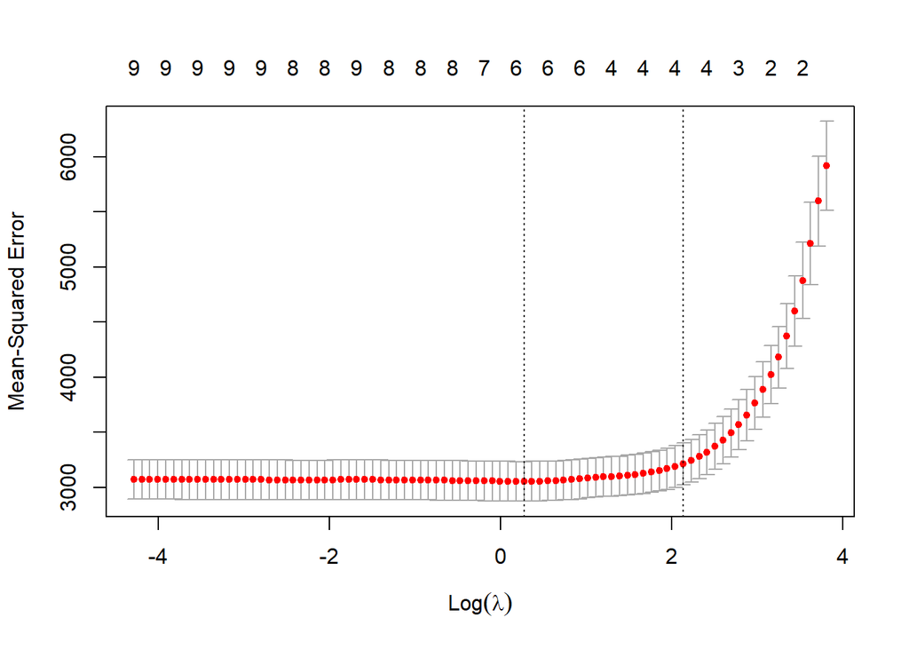

```r
# Plot
plot(lasso_cv)
```

# Question 6: Elastic Net Regularization - 5 points

1. Perform elastic net regression. Give equal weight to both penalties. Use 10-fold CV to find the optimal lambda value and display it. (3 points)

```r
# elastic net regression
elastic_net_cv <- cv.glmnet(x,y,alpha = 0.5,nfolds =10)
#check elastic net
check_elastic_net_1 = 0
optimal_lambda_enet <- elastic_net_cv$lambda.min
#return
optimal_lam_new_1 = "True"
optimal_lambda_enet
```

```
## [1] 2.632878
```

The optimal lambda for elastic net regression, found through 10-fold cross-validation with equal weighting for L1 and L2 penalties (alpha = 0.5), is approximately 2.6328. This value balances between the ridge and lasso penalties, combining their strengths in handling multicollinearity and variable selection.

2. Display the coefficients at optimal lambda. How many variables were selected by elastic net regression? (2 points)

```r
# Coefficients at optimal
elastic_net_model <-glmnet(x,y,alpha = 0.5,lambda =optimal_lambda_enet)
elastic_net_coefficients <-coef(elastic_net_model)
check_elastic_net_coeffs = 0

# non-zero coefficients
num_selected_vars_enet <-sum(elastic_net_coefficients!= 0)
elastic_net_coefficients
```

```
## 10 x 1 sparse Matrix of class "dgCMatrix"
##                     s0
## (Intercept)  152.13348
## age            .
## bmi          540.20881
## bp           249.75716
## s1           -90.54691
## s2             .
## s3          -147.96635
## s4             .
## s5           512.11045
## s6            34.50819
```

```r
check_elastic_iftrue = "True"
#return
num_selected_vars_enet
```

```
## [1] 7
```